# Week 2 Basic Classification Models: knn, Decision Trees, and Logistic Regressions

# Splitting Criterion

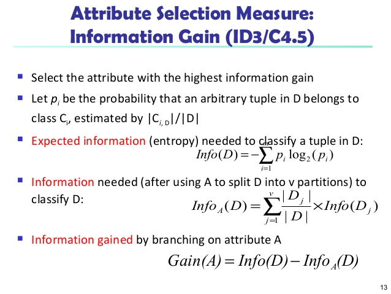

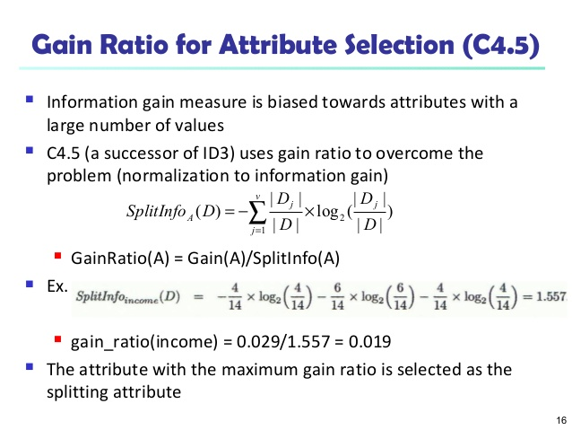

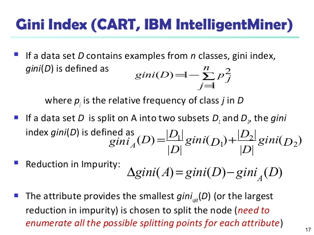

# Creating a Training and Test Set by Randomizing Observations

```r
set.seed(123) #set a seed to do draws from a random uniform distribution.
prescribers_rand <- prescribers[order(runif(25000)), ]
prescribers_train <- prescribers_rand[1:20000, ] #Training data set; 20000 observations
prescribers_test  <-prescribers_rand[20001:25000, ]
```

# Using rpart to Build a Decision Tree

```r
library(rpart)
set.seed(123)
prescribers_rpart <- rpart(prescribers_train$Opioid.Prescriber~., method="class", parms = list(split="gini"), data=prescribers_train)


#More on the method options:
# a. method="class" --> categorical (yes/no)
# b. method="anova" --> continuous
# c. method="poisson" --> count
# d. method="exp" --> survival analysis (in poverty/out of poverty)

#More on the parms option:
#a. The default splitting criterion is the Gini Index.
```

# Root, Nodes, and Leaves

```r
summary(prescribers_rpart)
```

```
## Call:
## rpart(formula = prescribers_train$Opioid.Prescriber ~ ., data = prescribers_train,
##     method = "class", parms = list(split = "gini"))
##   n= 20000
##
##           CP nsplit rel error    xerror        xstd
## 1 0.09197568      0 1.0000000 1.0000000 0.008460529
## 2 0.05933131      3 0.7221884 0.7262006 0.007869149
## 3 0.05215805      4 0.6628571 0.6628571 0.007656471
## 4 0.02759878      5 0.6106991 0.6282067 0.007526323
## 5 0.01313070      6 0.5831003 0.6014590 0.007418764
## 6 0.01000000      7 0.5699696 0.5722796 0.007294030
##
## Variable importance
##          LEVOTHYROXINE.SODIUM                 METFORMIN.HCL
##                            16                            12
##                   SIMVASTATIN                    LISINOPRIL
##                            11                            10
##           HYDROCHLOROTHIAZIDE          ATORVASTATIN.CALCIUM
##                            10                            10
##                       Surgeon            Emergency.Medicine
##                             7                             6
##                     MELOXICAM                    PREDNISONE
##                             4                             3
## SULFAMETHOXAZOLE.TRIMETHOPRIM                       SPIRIVA
##                             2                             1
##                 ADVAIR.DISKUS                     SYMBICORT
##                             1                             1
##            MONTELUKAST.SODIUM                      CELEBREX
##                             1                             1
##                TAMSULOSIN.HCL                    PROAIR.HFA
##                             1                             1
##           CYCLOBENZAPRINE.HCL                   FINASTERIDE
##                             1                             1
##
## Node number 1: 20000 observations,    complexity param=0.09197568
##   predicted class=yes  expected loss=0.41125  P(node) =1
##     class counts:  8225 11775
##    probabilities: 0.411 0.589
##   left son=2 (15112 obs) right son=3 (4888 obs)
```

[output cut: 138 more lines]

```
##
## Node number 65: 459 observations
##   predicted class=yes  expected loss=0.2527233  P(node) =0.02295
##     class counts:   116   343
##    probabilities: 0.253 0.747
##
## Node number 66: 244 observations
##   predicted class=no   expected loss=0.2786885  P(node) =0.0122
##     class counts:   176    68
##    probabilities: 0.721 0.279
##
## Node number 67: 1385 observations
##   predicted class=yes  expected loss=0.3061372  P(node) =0.06925
##     class counts:   424   961
##    probabilities: 0.306 0.694
```

# Visualizing the Decision Tree

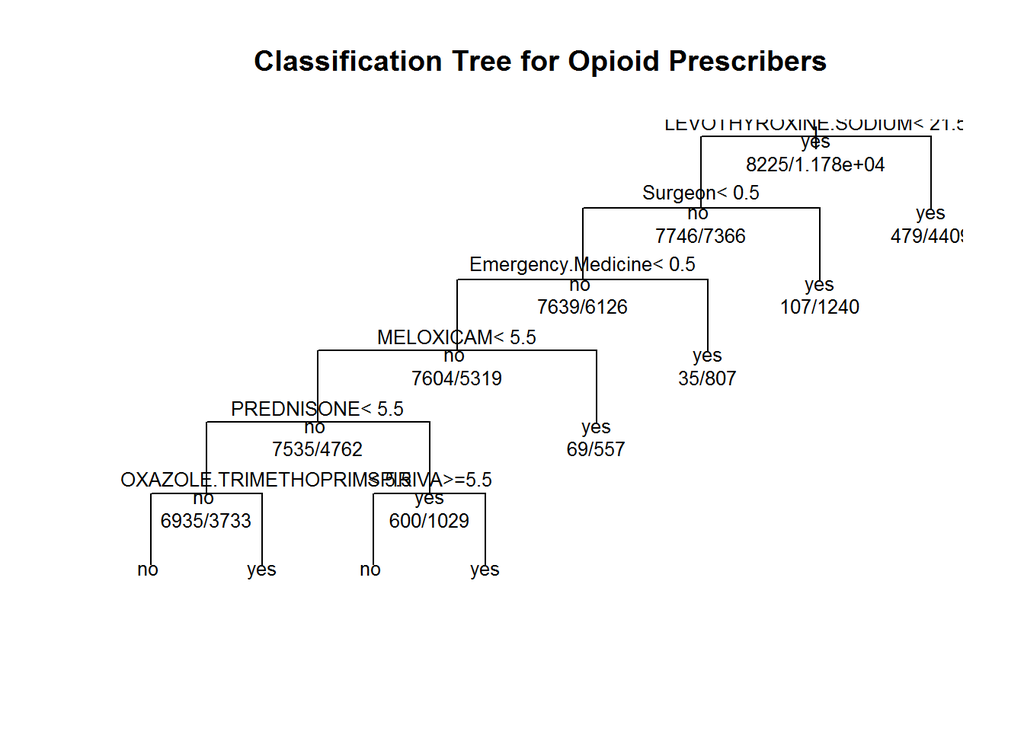

```r
plot(prescribers_rpart, uniform=TRUE, main="Classification Tree for Opioid Prescribers")
text(prescribers_rpart, use.n=TRUE, all=TRUE, cex=0.8)
```

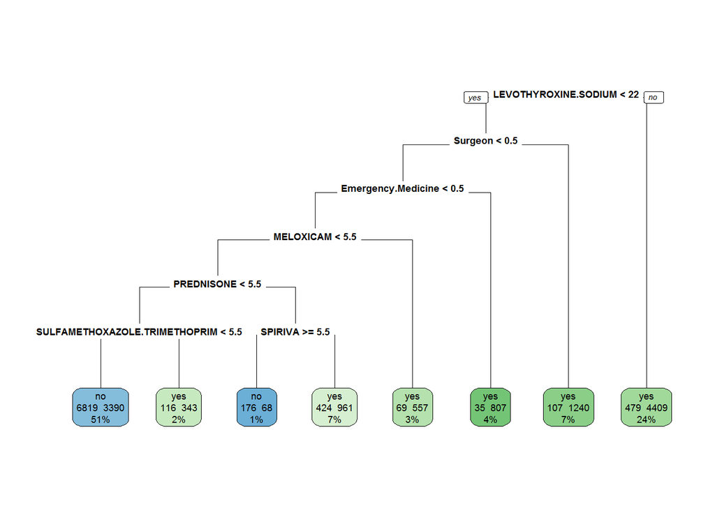

```r
# Something a bit fancier
library(rpart.plot)
rpart.plot(prescribers_rpart, type=0, extra=101)
```

The leaves show the opioid vs. non-opioid prescribers after the split at that node.

The blue indicates the majority in that subgroup is non-opioid prescribers (negatives). The green indicates the majority in that subgroup is opioid prescribers (positives).

The label (yes or no) at each node indicates the label of the majority subgroup (“yes” or “no” for being opioid prescribers).

Starting from the top, we have:

First split (Levothyroxine.sodium): There were 4,888 medical professionals who prescribed levothyroxine.sodium more than 22 times. Of these people, 4,409 were opioid prescribers and 479 who were not opioid prescribers. This subgroup makes up 24% of the training set [(4,888/20,000)*100% = 0.24].

Second split (Surgeon): There were 1,347 people out of this 15,112 subgroup who were surgeon (7% of the training set). Of these surgeons, 1,240 were opioid prescribers and 107 who were not opioid prescribers. And so on…

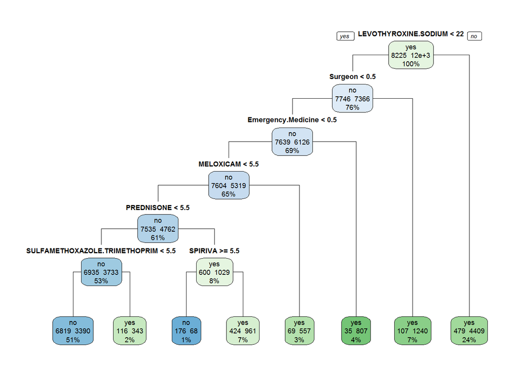

```r
rpart.plot(prescribers_rpart, type=1, extra=101)
```

The leaves show the opioid vs. non-opioid prescribers.

The nodes show the opioid vs. non-opioid prescribers before the next split.

The blue indicates the majority in that subgroup is non-opioid prescribers (negatives). The green indicates the majority in that subgroup is opioid prescribers (positives).

The label (yes or no) at each node indicates the label of the majority subgroup (“yes” or “no” for being opioid prescribers).

Starting from the top, we have:

20,000 people in training set: 8,225 who were not opioid prescribers, and 11,775 who were opioid prescribers. Since the majority of this group were opioid prescribers, the node is green and labeled as “yes.” First split (Levothyroxine.sodium): There were 4,888 medical professionals who prescribed levothyroxine.sodium more than 22 times. Of these people, 4,409 were opioid prescribers and 479 who were not opioid prescribers. This subgroup makes up 24% of the training set [(4,888/20,000)*100% = 0.24].

Now there were 15,112 people who prescribed levothyroxine.sodium less than 22 times (or 76% of the training set). Of this subgroup, 7,746 were not opioid prescribers and 7,366 who were opioid prescribers. Since the majority of this subgroup were not opioid prescribers, the node is blue and “no” is labeled.

Second split (Surgeon): There were 1,347 people out of this 15,112 subgroup who were surgeon (7% of the training set). Of these surgeons, 1,240 were opioid prescribers and 107 who were not opioid prescribers.

Now there were 13,765 who did prescribed levothyroxine.sodium less than 22 times AND were not surgeons. Of these people, 7,639 people who were not opioid prescribers and 6,126 people were opioid prescribers. And so on….

# Even fancier?

```r
library(party)
library(partykit)
```

[figure not shown]

```r
prescribers_party<-as.party(prescribers_rpart)
plot(prescribers_party)
```

Check out this [vignette](http://www.milbo.org/rpart-plot/prp.pdf) on plotting rpart objects with rpart.plot(). A good resource for formatting your decision trees.

# A Note on the Drugs in Decision Tree

LEVOTHROXINE.SODIUM: used to treat underactive thyroid (hypothyrodism).

MELOXICAM: nonsteroid anti-inflammatory drug.

PREDNISONE: uses to decease immune system’s responses to reduce sweling and allergic-type reactions.

SPIRIVA: controls and prevents symptons caused by ongoing lung disease.

SULFAMETHOZAZOLE.TRIMETHOPRIM: uses to treat wide variety of bacterial infections & certain type of pneumonia.

# Evaluating Model Performance

```r
library(caret)
actual <- prescribers_test$Opioid.Prescriber
predicted <- predict(prescribers_rpart, prescribers_test, type="class")
results.matrix <- confusionMatrix(predicted, actual, positive="yes")
print(results.matrix)
```

```
## Confusion Matrix and Statistics
##
##           Reference
## Prediction   no  yes
##        no  1761  877
##        yes  326 2036
##
##                Accuracy : 0.7594
##                  95% CI : (0.7473, 0.7712)
##     No Information Rate : 0.5826
##     P-Value [Acc > NIR] : < 2.2e-16
##
##                   Kappa : 0.5231
##  Mcnemar's Test P-Value : < 2.2e-16
##
##             Sensitivity : 0.6989
##             Specificity : 0.8438
##          Pos Pred Value : 0.8620
##          Neg Pred Value : 0.6676
##              Prevalence : 0.5826
##          Detection Rate : 0.4072
##    Detection Prevalence : 0.4724
##       Balanced Accuracy : 0.7714
##
##        'Positive' Class : yes
##
```

# Using the Complexity Parameter (CP Value) to Prune the Decision Tree

```r
cptable<-printcp(prescribers_rpart)
```

```
##
## Classification tree:
## rpart(formula = prescribers_train$Opioid.Prescriber ~ ., data = prescribers_train,
##     method = "class", parms = list(split = "gini"))
##
## Variables actually used in tree construction:
## [1] Emergency.Medicine            LEVOTHYROXINE.SODIUM
## [3] MELOXICAM                     PREDNISONE
## [5] SPIRIVA                       SULFAMETHOXAZOLE.TRIMETHOPRIM
## [7] Surgeon
##
## Root node error: 8225/20000 = 0.41125
##
## n= 20000
##
##         CP nsplit rel error  xerror      xstd
## 1 0.091976      0   1.00000 1.00000 0.0084605
## 2 0.059331      3   0.72219 0.72620 0.0078691
## 3 0.052158      4   0.66286 0.66286 0.0076565
## 4 0.027599      5   0.61070 0.62821 0.0075263
## 5 0.013131      6   0.58310 0.60146 0.0074188
## 6 0.010000      7   0.56997 0.57228 0.0072940
```

```r
cptable
```

```
##           CP nsplit rel error    xerror        xstd
## 1 0.09197568      0 1.0000000 1.0000000 0.008460529
## 2 0.05933131      3 0.7221884 0.7262006 0.007869149
## 3 0.05215805      4 0.6628571 0.6628571 0.007656471
## 4 0.02759878      5 0.6106991 0.6282067 0.007526323
## 5 0.01313070      6 0.5831003 0.6014590 0.007418764
## 6 0.01000000      7 0.5699696 0.5722796 0.007294030
```

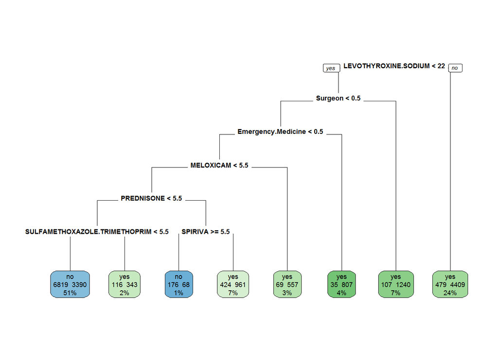

```r
set.cp.value<-cptable[which.min(cptable[,"xerror"]),"CP"]

Pruned_prescribers_rpart <- prune(prescribers_rpart, cp=set.cp.value)

rpart.plot(Pruned_prescribers_rpart, type=0, extra=101)
```

Well, that did not do anything! The tree is the same as before. This is due to the fact that the CP value continues to decrease with more splits. Time to try something else!

# Visualizing Cross Validation Results

This plots the size of tree (nsplit+1) on top and the complexity parameter at the bottom (x-axis). The red line is the minimum cross validated error (or xerror) + one standard deviation (or xstd).

```r
cptable<-printcp(prescribers_rpart)
```

```
##
## Classification tree:
## rpart(formula = prescribers_train$Opioid.Prescriber ~ ., data = prescribers_train,
##     method = "class", parms = list(split = "gini"))
##
## Variables actually used in tree construction:
## [1] Emergency.Medicine            LEVOTHYROXINE.SODIUM
## [3] MELOXICAM                     PREDNISONE
## [5] SPIRIVA                       SULFAMETHOXAZOLE.TRIMETHOPRIM
## [7] Surgeon
##
## Root node error: 8225/20000 = 0.41125
##
## n= 20000
##
##         CP nsplit rel error  xerror      xstd
## 1 0.091976      0   1.00000 1.00000 0.0084605
## 2 0.059331      3   0.72219 0.72620 0.0078691
## 3 0.052158      4   0.66286 0.66286 0.0076565
## 4 0.027599      5   0.61070 0.62821 0.0075263
## 5 0.013131      6   0.58310 0.60146 0.0074188
## 6 0.010000      7   0.56997 0.57228 0.0072940
```

```r
cptable
```

```
##           CP nsplit rel error    xerror        xstd
## 1 0.09197568      0 1.0000000 1.0000000 0.008460529
## 2 0.05933131      3 0.7221884 0.7262006 0.007869149
## 3 0.05215805      4 0.6628571 0.6628571 0.007656471
## 4 0.02759878      5 0.6106991 0.6282067 0.007526323
## 5 0.01313070      6 0.5831003 0.6014590 0.007418764
## 6 0.01000000      7 0.5699696 0.5722796 0.007294030
```

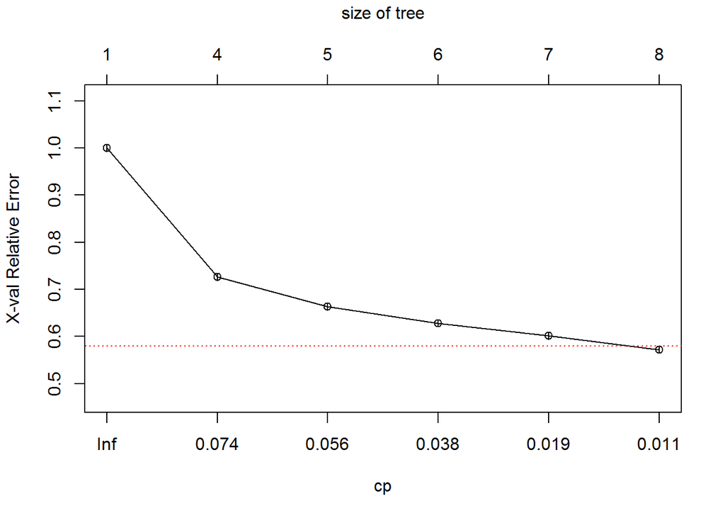

```r
plotcp(prescribers_rpart, minline=TRUE, col="red")
```

# Picking a Tree Size

Method 1: Look for the “elbow” in the CP plot. Set the tree size at the cp value where the “elbow” occurs.

Method 2: Pick the cp value that is within one standard deviation of the minimum xerror (the red line).

Method 3: Manually prune the tree until desired result is achieved.

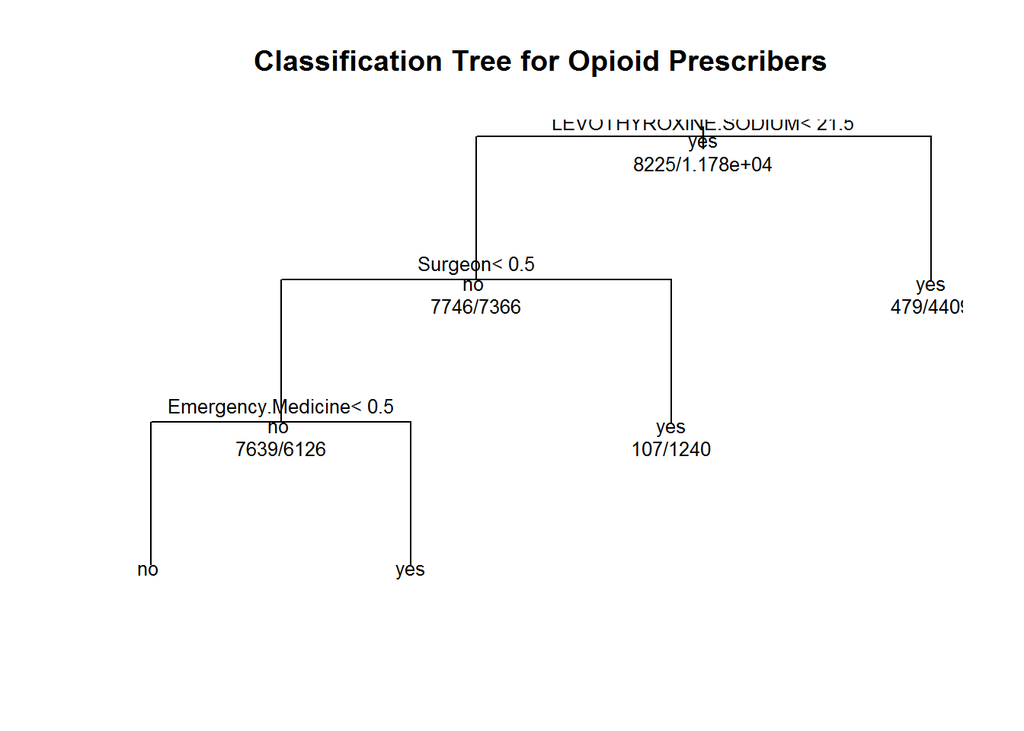

```r
Pruned_prescribers_rpart <-prune(prescribers_rpart,cp=.07) #Change the cp and see what happens.

plot(Pruned_prescribers_rpart, uniform=TRUE,main="Classification Tree for Opioid Prescribers")
text(Pruned_prescribers_rpart, use.n=TRUE, all=TRUE, cex=.8)
```

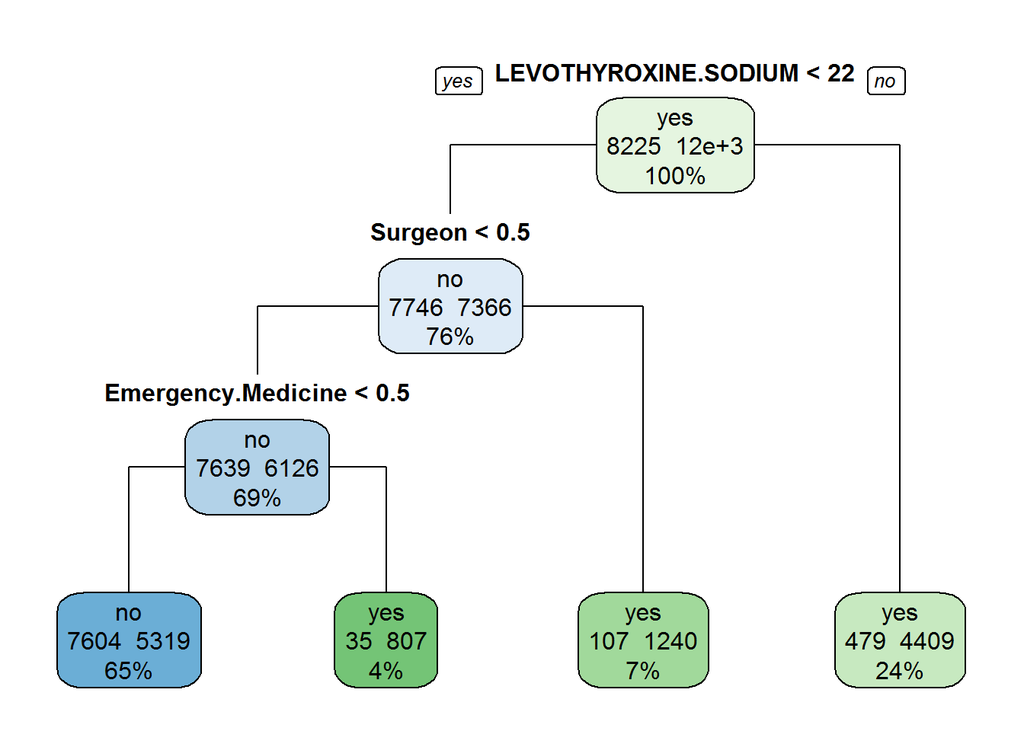

```r
rpart.plot(Pruned_prescribers_rpart, type=1, extra=101)
```

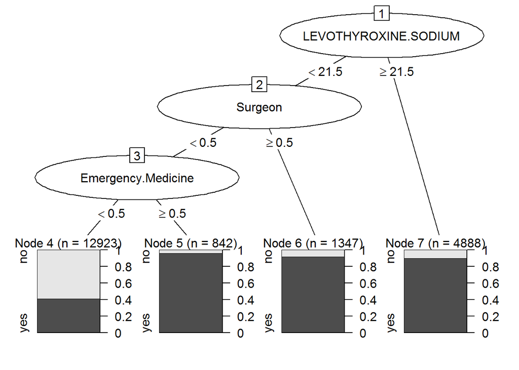

```r
Pruned_prescribers_party<-as.party(Pruned_prescribers_rpart)
plot(Pruned_prescribers_party)
```

```r
actual <- prescribers_test$Opioid.Prescriber
predicted <- predict(Pruned_prescribers_rpart, prescribers_test, type="class")
results.matrix <- confusionMatrix(predicted, actual, positive="yes")
print(results.matrix)
```

```
## Confusion Matrix and Statistics
##
##           Reference
## Prediction   no  yes
##        no  1931 1328
##        yes  156 1585
##
##                Accuracy : 0.7032
##                  95% CI : (0.6903, 0.7158)
##     No Information Rate : 0.5826
##     P-Value [Acc > NIR] : < 2.2e-16
##
##                   Kappa : 0.4347
##  Mcnemar's Test P-Value : < 2.2e-16
##
##             Sensitivity : 0.5441
##             Specificity : 0.9253
##          Pos Pred Value : 0.9104
##          Neg Pred Value : 0.5925
##              Prevalence : 0.5826
##          Detection Rate : 0.3170
##    Detection Prevalence : 0.3482
##       Balanced Accuracy : 0.7347
##
##        'Positive' Class : yes
##
```

How does accuracy look? Sensitivity? Specificity?

# Exploring rpart.control

You should play around with rpart.control to do additional tree pruning.

```r
#help(rpart.control)
```

# Logistic Regression

We fit the logistic regression using maximum likelihood. The idea behind maximum likelihood is that we seek estimates for B’s such that the predicted probability corresponds as closely as possible to the observed data. See here for more details:

https://en.wikipedia.org/wiki/Maximum_likelihood

Also refer to Section 4.3.2 in **James et al.** (page 133).

## Train Model

```r
prescribers_train_logit<-prescribers_train[,c(1,126,139,186,206,209,328,298)]

prescribers_train_logit$LEVOTHYROXINE.SODIUM.recode<-ifelse(prescribers_train_logit$LEVOTHYROXINE.SODIUM<22,"no","yes")

prescribers_train_logit$MELOXICAM.recode<-ifelse(prescribers_train_logit$MELOXICAM<6,"no","yes")

prescribers_train_logit$PREDNISONE.recode<-ifelse(prescribers_train_logit$PREDNISONE<6,"no","yes")

prescribers_train_logit$SPIRIVA.recode<-ifelse(prescribers_train_logit$SPIRIVA<6,"no","yes")

prescribers_train_logit$SULFAMETHOXAZOLE.TRIMETHOPRIM.recode<-
  ifelse(prescribers_train_logit$SULFAMETHOXAZOLE.TRIMETHOPRIM<6,"no","yes")

prescribers_train_logit[,c(2:6)]<-NULL

names(prescribers_train_logit)
```

```
## [1] "Opioid.Prescriber"
## [2] "Surgeon"
## [3] "Emergency.Medicine"
## [4] "LEVOTHYROXINE.SODIUM.recode"
## [5] "MELOXICAM.recode"
## [6] "PREDNISONE.recode"
## [7] "SPIRIVA.recode"
## [8] "SULFAMETHOXAZOLE.TRIMETHOPRIM.recode"
```

```r
prescriber.logit <- glm(Opioid.Prescriber~.+PREDNISONE.recode:SPIRIVA.recode+PREDNISONE.recode:SULFAMETHOXAZOLE.TRIMETHOPRIM.recode, data=prescribers_train_logit, family=binomial()) #Fit a logistic regression
summary(prescriber.logit) #coefficients are presented as log-odds (probabilities on logit scale)
```

```
##
## Call:
## glm(formula = Opioid.Prescriber ~ . + PREDNISONE.recode:SPIRIVA.recode +
##     PREDNISONE.recode:SULFAMETHOXAZOLE.TRIMETHOPRIM.recode, family = binomial(),
##     data = prescribers_train_logit)
##
## Deviance Residuals:
##     Min       1Q   Median       3Q      Max
## -3.2603  -0.8932   0.1543   0.8094   1.4913
##
## Coefficients:
##                                                              Estimate
## (Intercept)                                                  -0.71309
## Surgeon                                                       2.91763
## Emergency.Medicine                                            3.28845
## LEVOTHYROXINE.SODIUM.recodeyes                                1.57657
## MELOXICAM.recodeyes                                           2.22072
## PREDNISONE.recodeyes                                          1.33480
## SPIRIVA.recodeyes                                             0.52841
## SULFAMETHOXAZOLE.TRIMETHOPRIM.recodeyes                       1.66086
## PREDNISONE.recodeyes:SPIRIVA.recodeyes                       -1.16724
## PREDNISONE.recodeyes:SULFAMETHOXAZOLE.TRIMETHOPRIM.recodeyes -0.77007
##                                                              Std. Error
## (Intercept)                                                     0.02072
## Surgeon                                                         0.10320
## Emergency.Medicine                                              0.17548
## LEVOTHYROXINE.SODIUM.recodeyes                                  0.05926
## MELOXICAM.recodeyes                                             0.09806
## PREDNISONE.recodeyes                                            0.05942
## SPIRIVA.recodeyes                                               0.12217
## SULFAMETHOXAZOLE.TRIMETHOPRIM.recodeyes                         0.09962
## PREDNISONE.recodeyes:SPIRIVA.recodeyes                          0.15787
## PREDNISONE.recodeyes:SULFAMETHOXAZOLE.TRIMETHOPRIM.recodeyes    0.15926
##                                                              z value
## (Intercept)                                                  -34.423
## Surgeon                                                       28.271
## Emergency.Medicine                                            18.740
## LEVOTHYROXINE.SODIUM.recodeyes                                26.603
## MELOXICAM.recodeyes                                           22.646
## PREDNISONE.recodeyes                                          22.465
```

[output cut: 10 more lines]

```
## PREDNISONE.recodeyes                                          < 2e-16 ***
## SPIRIVA.recodeyes                                            1.52e-05 ***
## SULFAMETHOXAZOLE.TRIMETHOPRIM.recodeyes                       < 2e-16 ***
## PREDNISONE.recodeyes:SPIRIVA.recodeyes                       1.43e-13 ***
## PREDNISONE.recodeyes:SULFAMETHOXAZOLE.TRIMETHOPRIM.recodeyes 1.33e-06 ***
## ---
## Signif. codes:  0 '***' 0.001 '**' 0.01 '*' 0.05 '.' 0.1 ' ' 1
##
## (Dispersion parameter for binomial family taken to be 1)
##
##     Null deviance: 27092  on 19999  degrees of freedom
## Residual deviance: 19455  on 19990  degrees of freedom
## AIC: 19475
##
## Number of Fisher Scoring iterations: 6
```

```r
exp(cbind(Odds_Ratio=coef(prescriber.logit))) #Take exponent of log odds gives "odds" ratio.
```

```
##                                                              Odds_Ratio
## (Intercept)                                                   0.4901297
## Surgeon                                                      18.4974687
## Emergency.Medicine                                           26.8013926
## LEVOTHYROXINE.SODIUM.recodeyes                                4.8383479
## MELOXICAM.recodeyes                                           9.2139446
## PREDNISONE.recodeyes                                          3.7992499
## SPIRIVA.recodeyes                                             1.6962381
## SULFAMETHOXAZOLE.TRIMETHOPRIM.recodeyes                       5.2638321
## PREDNISONE.recodeyes:SPIRIVA.recodeyes                        0.3112246
## PREDNISONE.recodeyes:SULFAMETHOXAZOLE.TRIMETHOPRIM.recodeyes  0.4629784
```

The odds of an Emergency Medicine (EM) doctor prescribing opioids is 27 times higher than their non-EM counterparts.

The odds of a Surgeon prescribing opioids is 18 times higher than their non-Surgeon counterparts.

And so on…

# Is the Logistic Regression Model Statistically Significant?

To see whether the model is statistically significant, we can use anova(). Note below that we should see the residual deviance decreasing with each additional predictor being added to the null model. If the addition of a predictor does not decrease the residual deviance by much, we should consider excluding that predictor from our model.

```r
anova(prescriber.logit,test="Chisq")
```

```
## Analysis of Deviance Table
##
## Model: binomial, link: logit
##
## Response: Opioid.Prescriber
##
## Terms added sequentially (first to last)
##
##
##                                                        Df Deviance
## NULL
## Surgeon                                                 1    821.7
## Emergency.Medicine                                      1    759.9
## LEVOTHYROXINE.SODIUM.recode                             1   3836.0
## MELOXICAM.recode                                        1   1090.6
## PREDNISONE.recode                                       1    686.0
## SPIRIVA.recode                                          1      0.4
## SULFAMETHOXAZOLE.TRIMETHOPRIM.recode                    1    359.7
## PREDNISONE.recode:SPIRIVA.recode                        1     60.9
## PREDNISONE.recode:SULFAMETHOXAZOLE.TRIMETHOPRIM.recode  1     22.6
##                                                        Resid. Df
## NULL                                                       19999
## Surgeon                                                    19998
## Emergency.Medicine                                         19997
## LEVOTHYROXINE.SODIUM.recode                                19996
## MELOXICAM.recode                                           19995
## PREDNISONE.recode                                          19994
## SPIRIVA.recode                                             19993
## SULFAMETHOXAZOLE.TRIMETHOPRIM.recode                       19992
## PREDNISONE.recode:SPIRIVA.recode                           19991
## PREDNISONE.recode:SULFAMETHOXAZOLE.TRIMETHOPRIM.recode     19990
##                                                        Resid. Dev
## NULL                                                        27092
## Surgeon                                                     26271
## Emergency.Medicine                                          25511
## LEVOTHYROXINE.SODIUM.recode                                 21675
## MELOXICAM.recode                                            20584
## PREDNISONE.recode                                           19898
## SPIRIVA.recode                                              19898
## SULFAMETHOXAZOLE.TRIMETHOPRIM.recode                        19538
## PREDNISONE.recode:SPIRIVA.recode                            19477
## PREDNISONE.recode:SULFAMETHOXAZOLE.TRIMETHOPRIM.recode      19455
##                                                         Pr(>Chi)
## NULL
## Surgeon                                                < 2.2e-16 ***
## Emergency.Medicine                                     < 2.2e-16 ***
## LEVOTHYROXINE.SODIUM.recode                            < 2.2e-16 ***
## MELOXICAM.recode                                       < 2.2e-16 ***
## PREDNISONE.recode                                      < 2.2e-16 ***
## SPIRIVA.recode                                            0.5185
## SULFAMETHOXAZOLE.TRIMETHOPRIM.recode                   < 2.2e-16 ***
## PREDNISONE.recode:SPIRIVA.recode                       6.049e-15 ***
## PREDNISONE.recode:SULFAMETHOXAZOLE.TRIMETHOPRIM.recode 2.004e-06 ***
## ---
## Signif. codes:  0 '***' 0.001 '**' 0.01 '*' 0.05 '.' 0.1 ' ' 1
```

## Validate Model

```r
prescribers_test_logit<-prescribers_test[,c(1,126,139,186,206,209,328,298)]

prescribers_test_logit$LEVOTHYROXINE.SODIUM.recode<-ifelse(prescribers_test_logit$LEVOTHYROXINE.SODIUM<22,"no","yes")

prescribers_test_logit$MELOXICAM.recode<-ifelse(prescribers_test_logit$MELOXICAM<6,"no","yes")

prescribers_test_logit$PREDNISONE.recode<-ifelse(prescribers_test_logit$PREDNISONE<6,"no","yes")

prescribers_test_logit$SPIRIVA.recode<-ifelse(prescribers_test_logit$SPIRIVA<6,"no","yes")

prescribers_test_logit$SULFAMETHOXAZOLE.TRIMETHOPRIM.recode<-
  ifelse(prescribers_test_logit$SULFAMETHOXAZOLE.TRIMETHOPRIM<6,"no","yes")

prescribers_test_logit[,c(2:6)]<-NULL
```

### Prediction as log-odds

```r
prescribers_test_logit$predict.opioid.prescriber<-predict(prescriber.logit, newdata=prescribers_test_logit) #the predictions are in log-odds. Not user friendly.
```

```r
prescribers_test_logit$predict.opioid.prescriber<-predict(prescriber.logit, newdata=prescribers_test_logit,type="response") #convert into probabilities.

#probability = exp(log odds)/[1 + exp(log odds))]
#same as probability = odds/(1+odds)
```

### 95% confidence interval for predicted probability

```r
prescribers_test_logit[,9]<-NULL

prescribers_test_logit_CI<-cbind(prescribers_test_logit,predict(prescriber.logit, newdata=prescribers_test_logit,type="link",se=TRUE))

prescribers_test_logit_CI <- within(prescribers_test_logit_CI,
  {
    PredictedProb <- plogis(fit)
    LL <- plogis(fit - (1.96 * se.fit))
    UL <- plogis(fit + (1.96 * se.fit))
    })
```